# Lesson 123 · Temporal heterogeneous graphs: what may this query see?

Teacher reference · Three live functions sample and audit synthetic and real temporal graphs. PROVIDED = inspect; TODO = implement; CHECK = execute unchanged; EXIT = defend. Default execution audits nine queries on the full temporal graph and rescores author predictions; full GPU training is separately gated. Learner status PENDING_WRITTEN_DEFENSE.

```python
# @colab-bootstrap: install missing dependencies; report actual versions.
import importlib.util,importlib.metadata,subprocess,sys
required={'numpy':'numpy','pandas':'pandas','pyarrow':'pyarrow','torch':'torch','torch_frame':'pytorch-frame==0.2.3','torch_geometric':'torch-geometric==2.6.1','relbench':'relbench==1.1.0','pooch':'pooch'}
missing=[package for module,package in required.items() if importlib.util.find_spec(module) is None]
if missing:subprocess.check_call([sys.executable,'-m','pip','install',*missing])
print('Actual notebook runtime:',sys.version)
print({k:importlib.metadata.version(k) for k in ['numpy','pandas','torch','pytorch-frame','torch-geometric','relbench']})
```

```
Actual notebook runtime: 3.12.3 (main, Aug 31 2026, 10:18:26) [GCC 13.3.0]
{'numpy': '2.5.0', 'pandas': '3.0.3', 'torch': '2.13.0+cpu', 'pytorch-frame': '0.3.0', 'torch-geometric': '2.8.0.post1', 'relbench': '1.1.0'}
```

From Lesson 122 to this lesson

Correct key mapping does not prevent future context. Construct a separate legal neighborhood for each entity-time question.

**Quick prerequisite reminder**

A seed is the entity being predicted. A node occurrence is its copy inside one sampled query graph. Here every hop uses the root cutoff; TGAT in L103 used decreasing child cutoffs.

## 1 · A correct graph can still answer with tomorrow's information

[Lesson 122](https://avistian.github.io/relational/lessons/0122-reg-construction.html) established which rows and foreign keys belong in the relational entity graph (REG). A REG represents each table as a node type, each row as a node, and each foreign-key role as an edge type. Now fix a **query**: predict something about one entity using information available at time **t**. The graph can contain many dates, but this query may see only its eligible neighborhood. Our skill is to construct that neighborhood and defend every included row and relationship.

Read [Fey et al., Sections 3–4](https://proceedings.mlr.press/v235/fey24a.html) for the RDL blueprint, then [RelBench v1, Sections 2–3](https://arxiv.org/html/2407.20060v1) for the released temporal sampling setting. Our real-data experiment uses RelBench; our delayed-arrival example adds an explicit availability contract that the F1 release cannot establish.

**Your tangible deliverable:** a two-hop, typed neighborhood for a seed entity at time t, plus an audit. A **seed** is the entity whose prediction we request. A **hop** expands one relation into the rows that can send information toward the seed. Three live notebook functions implement visibility, sampling, and auditing. They also run on the complete released F1 topology.

This connects the mission directly to evidence: if a relational model sees future race results, its lower prediction error cannot establish useful predictive advantage. Temporal splits and a correct static graph do not by themselves settle what each individual prediction saw.

## 2 · Which clock controls visibility?

A timestamp needs a meaning. Distinguish these before assigning tensors:

| Quantity | Meaning | Example |
| --- | --- | --- |
| Entity creation time | When this entity first exists | Account opened on day 2 |
| Event time | When an observation occurs | Transfer happened on day 5 |
| Availability time | When the system can use that observation | Transfer imported on day 11 |
| Query / seed time t | When the prediction is made | Predict at day 8 |
| Label maturity time | When the future outcome is fully observed | A 7-day target becomes known after its window |

A transfer that happened on day 5 but arrived on day 11 is invisible to a query on day 8. Our teaching contract is **event ≤ t AND availability ≤ t**. All quantities in the worked example are integer days on one common clock. In F1, tensors use integer Unix seconds; task artifacts also retain original timestamps for query identity. Never compare seconds with nanoseconds.

```
# An explicit two-clock record, not a fabricated real ingestion history:
stamp = (5, 11)  # (event day, availability day)
# eligible(stamp, 8) must be False
```

We use an inclusive boundary: an observation at exactly t is eligible. This matches the pinned native sampler's upper-bound search. It is a declared convention, not a universal guarantee about simultaneous events: if order within a timestamp is unknown, the application needs a stricter cutoff or sequence key. [Pinned pyg-lib 0.4.0 temporal kernel](https://github.com/pyg-team/pyg-lib/blob/0.4.0/pyg_lib/csrc/sampler/cpu/neighbor_kernel.cpp).

**Task 1:** implement `eligible(stamp, cutoff)`. Reject unknown/nonfinite timestamp values and availability before event time. In this exercise, `None` means **explicitly assumed timeless**; it never means “a missing timestamp is safe.” That sentinel is an assumption you must defend.

Feature histories matter too. An account may have existed yesterday, while its current balance includes today's payment. Filtering entity creation times cannot restore the historical balance. The same is true of a corrected result, a changed foreign key, and a label that has not yet matured. These are separate data contracts; timestamped sampling cannot recover missing histories.

## 3 · Keep the original query cutoff at every hop

Use this small graph throughout. Person0 is assumed timeless. Transfers point to their receiver, Person0. Memos point to the transfer they describe. Arrows indicate message direction toward the seed; sampling walks incoming arrows backwards to gather context.

| Node | Event day | Available day | Incoming message destination |
| --- | --- | --- | --- |
| Transfer0 | 4 | 4 | Person0 |
| Transfer1 | 9 | 9 | Person0 |
| Transfer2 | 5 | 11 | Person0 |
| Memo0 | 12 | 12 | Transfer0 |
| Memo1 | 7 | 7 | Transfer0 |

**Predict before looking:** for Person0 at t=8, which transfer and which memo can contribute? Is Memo1 excluded because it is newer than Transfer0?

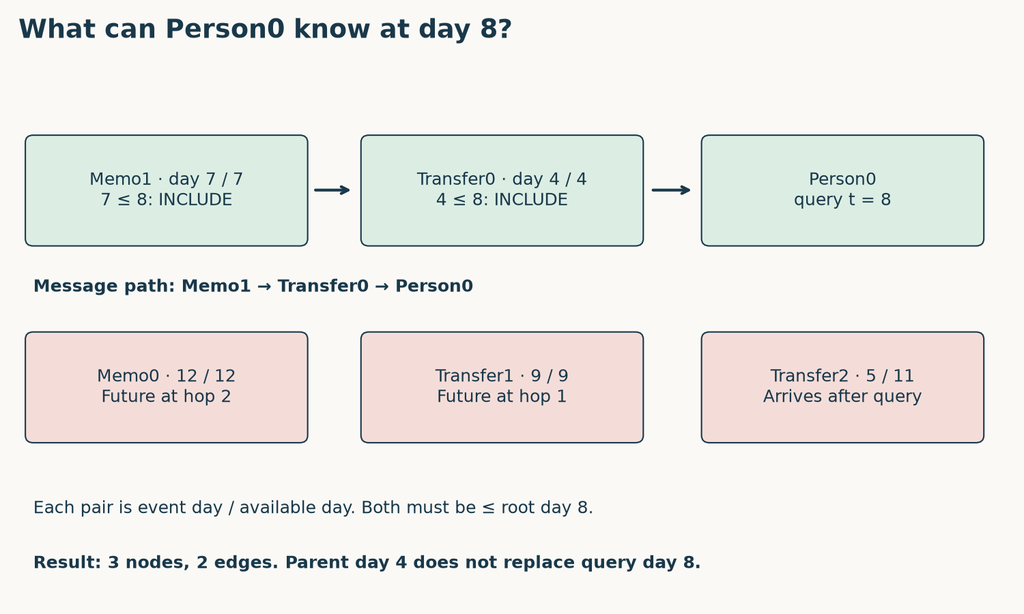

Synthetic day8 snapshot: Memo1 at day7 may inform Transfer0 at day4. Every hop uses root day8. Transfer2 occurred on day5 but arrived on day11.

At hop 1, only Transfer0 is eligible. Transfer1 is in the future; Transfer2 arrived late. At hop 2, Memo1 is eligible because day 7 ≤ the **root query's day 8**. Memo0 is excluded. The result has three nodes and two edges: Memo1 → Transfer0 → Person0.

Do not replace the root cutoff with the intermediate node's day 4. That would incorrectly remove a memo already known at query time. Conversely, filtering only hop 1 lets day-12 Memo0 enter at hop 2. This is a neighborhood representing a database snapshot at t; it is not a chronological event walk requiring decreasing event times along every path.

**Task 2:** implement `sample_temporal(nodes, edges, root, cutoff, hops)`. Build an incoming-edge index, expand eligible predecessors, keep the original cutoff, and retain node types and original edge identities. A frontier is the newly discovered set to expand next. A seen set prevents repeatedly expanding the same node in this exhaustive breadth-first traversal. With zero hops, return only the eligible root. Reject a future root or unknown endpoint.

Our reference sampler returns **all** eligible incoming neighbors and is deterministic. The full released trainer bounds cost by sampling fanouts `[128,64]`: at most 128 neighbors per relation/target at the first expansion and 64 at the second. Uniform sampling is a separate stochastic choice after temporal eligibility. Exact selected neighbors need not match across random engines; our native parity test therefore uses fanout `[-1,-1]`, meaning all neighbors. [Released loader](https://github.com/snap-stanford/relbench/blob/9aa346267c2e1c560bd92da07d6f4ad1ca2f0639/examples/gnn_node.py).

## 4 · Edges and reverse relations also need a visibility contract

In our main fixture, each FK relation is assumed to be known when its row is known. We still test a separate relationship that becomes available on day 9 although both endpoint rows existed on day 4. At t=8 its endpoints may be present, but the link must be excluded. **Both endpoints and the relationship must be eligible.**

A reverse edge changes the direction in which information can flow; it does not change when the underlying relationship became available. If you explicitly timestamp forward edges, the reverse store must preserve the same relationship time. Do not give reverse edges an artificial ancient timestamp to make sampling convenient.

The released F1 graph stores timestamps on dated **nodes**, not separately observed relationship-availability times. The source constructor attaches `table.time_col` to the node store and constructs PK/FK links plus reverse relations. This lesson therefore audits real endpoint timestamps and edge identity, while leaving unobserved relationship updates unverified. [Pinned constructor](https://github.com/snap-stanford/relbench/blob/9aa346267c2e1c560bd92da07d6f4ad1ca2f0639/relbench/modeling/graph.py).

**Task 3:** implement `audit_sample`. Verify the root is present, every included node is visible, every edge identity exists, both endpoints belong to this sample, and any explicit relationship timestamp is eligible. This audit proves visibility and endpoint closure. It does **not** prove that all eligible nodes were included or that every node lies within the requested hop distance. Independent SQL and native-loader comparisons supply those additional checks for our tested queries.

**A passing visibility audit can still hide an incomplete sampler.** At day8, compare three proposed outputs for the same two-hop request:

| Returned sample | Visibility audit | Exact two-hop result? |
| --- | --- | --- |
| Person0 alone | PASS | No |
| Person0, Transfer0, Memo1; both edges | PASS | Yes |
| All six nodes and five edges | FAIL | No |

The root-only output contains no illegal row or edge, so the narrow audit correctly passes it. It still misses two eligible nodes and their message path. Comparing with an independent exhaustive query catches that omission. Conversely, a sampled-fanout contract may intentionally omit eligible neighbors; it needs the declared sampling checks rather than equality with the exhaustive result. Name the property you checked before reporting “PASS.”

**Try the contract change.** Keep the root-only output but change the requested hop count from 2 to 0. Does its visibility change? Does its completeness change?

**Check the audit scope**

Visibility is unchanged and still passes. The root-only output is now the exact requested zero-hop result. A check of returned timestamps cannot infer the intended hop budget or sampling policy; those belong to the construction contract.

## 5 · One entity, two prediction times

Person0 at day 8 and Person0 at day 12 are two queries. They share the same global entity identity but need different local neighborhoods. At day 12, all six nodes and five edges in the fixture are visible. A batch that merges them into one shared neighborhood can let the earlier prediction receive later information.

The released temporal loader uses **disjoint query components**: a row may appear twice, once per seed query. A component is one query's local graph. `n_id` maps a local row to its global row; `batch` maps it to its query index; `seed_time[batch]` supplies that query's cutoff. An edge must connect rows with the same query index. [Pinned PyG sampler](https://github.com/pyg-team/pytorch_geometric/blob/2.6.1/torch_geometric/sampler/neighbor_sampler.py).

```
for kind, times in batch.time_dict.items():
    query = batch[kind].batch
    assert (times <= batch['drivers'].seed_time[query]).all()
# Also verify edges stay inside one query and retain original global endpoints.
```

**Predict an intervention:** leave the graph and event days fixed, then ignore availability. At t=8, how many extra nodes and edges enter? Restore the rule, then move the cutoff to day 12.

Static trace: at day8, Memo1 → Transfer0 → Person0 gives3 nodes/2 edges. Ignoring availability adds Transfer2:4 nodes/3 edges. At day12 all6 nodes/5 edges are visible.

The first intervention incorrectly adds Transfer2: four nodes and three edges instead of three and two. The second intentionally changes the information set by changing prediction time. These are different causal changes. The fixed day-8 baseline remains visible beside the control.

## 6 · Audit the complete real F1 graph

The real-data lane retains all **74,063 released rows and 338,842 directed edges** from Lesson 122's graph. Six dated table types contain **72,918 rows**. Circuits, drivers and constructors have no released table timestamp; our checks report that assumption rather than inventing creation dates. The portable notebook embeds the complete topology and node-time arrays with hashes; it contains no fitted row-feature payloads.

**Real temporal audit: PASS.** Exact SQL node sets and PyG typed node/edge sets for nine specified queries.

| Split | Driver row | Unix cutoff (seconds) | Nodes | Edges |
| --- | --- | --- | --- | --- |
| train | 10 | 1088985600 | 99 | 245 |
| train | 10 | 1083801600 | 75 | 179 |
| train | 677 | -492134400 | 47 | 72 |
| val | 7 | 1249689600 | 570 | 1517 |
| val | 3 | 1208217600 | 420 | 1124 |
| val | 14 | 1140825600 | 530 | 1341 |
| test | 835 | 1464480000 | 1 | 0 |
| test | 817 | 1376352000 | 1 | 0 |
| test | 16 | 1283040000 | 545 | 1465 |

[Full temporal report](https://avistian.github.io/relational/labs/_temporal_audit_l123_results.json). Equal-time, future-second-hop and mixed-query mutation checks are separate.

The audit selects first/middle/last queries from each of train, validation and test. For all nine queries, the learner's exhaustive two-hop node set agrees with an independent recursive SQL query, and its typed nodes/edges agree with PyG. A further two-query check uses the **same driver at different times**. This is exact parity on these specified queries, not exhaustive equivalence for every possible root.

Two selected test drivers have no historical neighbors in the released graph and therefore yield only the root. That is a meaningful cold-start case. The release's database is censored at its test cutoff; a later test query does not automatically obtain newly occurring test-period rows. Do not silently append them and call the changed information set a source replay. [RelBench v1 data split contract](https://arxiv.org/html/2407.20060v1).

The real notebook harness calls **your** sampler and auditor on all nine queries. Synthetic delayed-arrival tasks and the real event-time checks answer different questions. F1 ingestion timestamps, mutable-feature histories and historical static-table membership remain unavailable.

## 7 · Follow the sampled graph through the full model

This is the same released RDL model introduced in L117 and used in L122; the new mechanism is the visibility audit surrounding every batch. Trace one driver query all the way to its prediction:

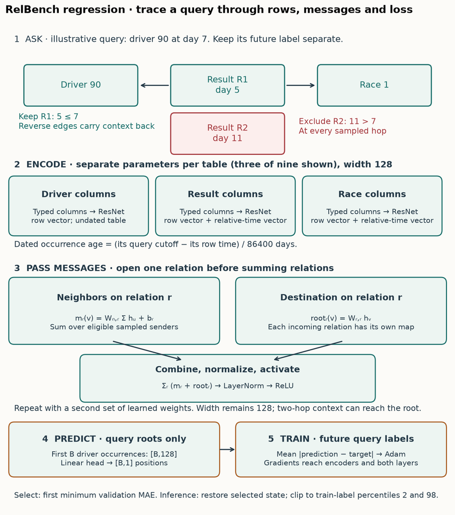

Released RelBench RDL pipeline reused from L117: typed row encoders, query-relative time, two GraphSAGE rounds and seed prediction. L123 audits each sampled batch.

**Diagram trace.** Find the query cutoff at sampling. Can the neural encoder repair a future row admitted before it? On a narrow screen, scroll the figure sideways.

1. The graph stores each table's typed columns in a `TensorFrame`, a container for numerical, categorical, timestamp and text features. Released per-table feature encoders and a four-block row ResNet map each sampled row to 128 learned coordinates.
2. The model subtracts a row timestamp from its **own seed query time**, converts the difference to days, and adds a learned encoding of that relative age. This tells the model how old an eligible observation is; it does not make a future observation eligible.
3. Two heterogeneous GraphSAGE rounds aggregate messages with relation-specific transforms and sum aggregation, then normalization/ReLU. The seed driver's scalar head predicts finishing position. Shapes contract from sampled context to seed outputs: the final loss uses `[number of seed queries, 1]`, not one supervised target for every context row.
4. Adam minimizes mean absolute error (MAE), the average absolute difference between predicted and target position. Validation MAE selects the first best epoch; the test labels do not choose checkpoints.

The complete visible model, graph materializer, temporal encoding, training loop and primitive source excerpts are in both notebooks. The training gate uses those same definitions. Our standalone teaching sampler is an exhaustive pedagogical implementation; full reproduction uses the native bounded loader with transparent audits. We do not replace the released sampling algorithm with the small reference implementation.

## 8 · Full selected reproduction and its evidence boundary

**Named experiment:** Robinson et al., RelBench v1 **Table 7, F1 `driver-position`, RDL**. Five fresh full-data fits use ten epochs each, all 7,453 training queries each epoch, batch size 512, width 128, two layers, fanouts `[128,64]`, uniform temporal sampling, and Adam with learning rate .005. Seeds are 0–4 after preprocessing seed 42. Predictions are clipped to training-label 2nd/98th percentiles as in the released path. Published validation/test targets are 3.193/4.022 MAE. [Paper, Table 7 and Appendix B](https://arxiv.org/html/2407.20060v1).

Source is pinned at `9aa346267c2e1c560bd92da07d6f4ad1ca2f0639`; database, task archive, text model and runtime are pinned too. The wrapper audits every training and evaluation batch without consuming random numbers: original node timestamps, each row's query cutoff, original edge identities and query isolation. The budgeted pilot gates five fresh runs. [Protocol and exact commands](https://avistian.github.io/relational/labs/l123-reproduction.md).

**Predict before reading:** if no timestamp violations occur but the score differs from the paper, does that establish a sampling bug? No: a temporal invariant and a predictive score test different claims. Our predeclared “CLOSE” threshold is an absolute mean difference of 0.2 MAE; it is descriptive, not a statistical equivalence test.

**Fresh author-reference execution: COMPLETE selected released-protocol experiment.**

| Split | Mean MAE | Sample seed SD | Published mean | Verdict |
| --- | --- | --- | --- | --- |
| val | 3.171187 | 0.050901 | 3.193 | CLOSE |
| test | 4.064913 | 0.069904 | 4.022 | CLOSE |

| Seed | Selected epoch | Validation MAE | Test MAE |
| --- | --- | --- | --- |
| 0 | 9 | 3.144878 | 3.971446 |
| 1 | 9 | 3.124080 | 4.010469 |
| 2 | 10 | 3.191524 | 4.132490 |
| 3 | 10 | 3.144670 | 4.110226 |
| 4 | 7 | 3.250785 | 4.099933 |

All **6,295** final predictions were independently scored. Maximum original-model output discrepancy: **3.81e-06**. Measured pilot plus full-fit worker resource estimate: **USD 0.0596**, excluding unitemized overhead. The aggregate plan caps reservations plus overhead reserve at USD 10. [Evidence](https://avistian.github.io/relational/labs/evidence/l123/summary.json).

Every training/evaluation batch passed timestamp, original-edge and query-isolation audits across **403,895 query occurrences** (repeated across epochs). [Audit example](https://avistian.github.io/relational/labs/evidence/l123/paper/seed-0/temporal-audit.json).

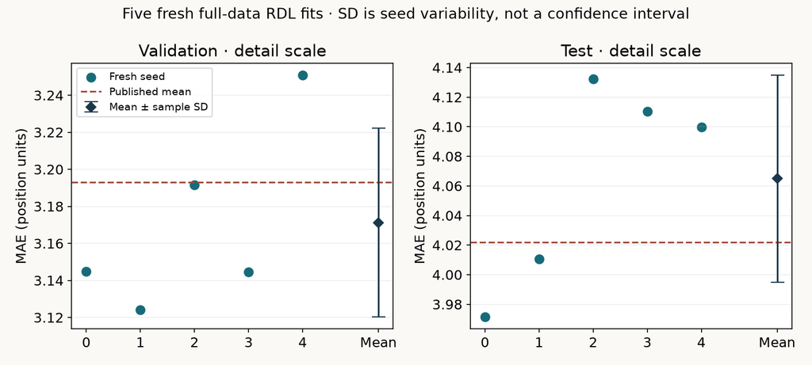

Fresh five-seed author results. Each point is one complete fit; diamond/error bar is mean plus or minus sample seed SD. Separate detail scales; dashed lines are published targets.

**Deviation ledger:** the release uses `[128,64]` fanouts versus the paper table's 128; historical seed identities are unavailable; preprocessing type inference is fixed at seed 42; the pinned modern runtime/text revision does not reconstruct historical binaries. The release computes preprocessing statistics from the database up to the test cutoff rather than fitting them solely on training-visible rows. We preserve and disclose that behavior for source replay. A per-query node cutoff therefore does not establish an entirely point-in-time-clean feature pipeline.

A completed selected experiment is evidence about this named release protocol. It does not establish the entire RelBench paper, Fey's beta experiments, historical bitwise identity, unseen ingestion histories, or your own mastery. The author predictions can be rescored offline; this is not a new fit in your notebook. Your status remains **PENDING_WRITTEN_DEFENSE**.

## 9 · EXIT: defend what the query could know

Submit your three functions, the nine real query audit results, and a written defense:

1. At t=8, explain each accepted and rejected row in the worked graph. Why is Memo1 valid despite being newer than Transfer0?
2. Explain the exact-time boundary, delayed arrival, and a mutable feature that node filtering cannot repair.
3. Trace local index → global identity → query index → cutoff for the same driver at two times. What must hold for every edge?
4. Give a sample that passes the visibility audit but is incomplete. Which independent comparison detects it?
5. Separate the full selected replay, real event-time checks, unavailable availability histories, and whole-paper parity.

Explain why every hop uses the root query cutoff, then give a delayed-arrival counterexample.

[Student lab](https://avistian.github.io/relational/labs/0123-temporal-heterogeneous-graphs.ipynb) · [Executed solution](https://avistian.github.io/relational/labs/html/0123-temporal-heterogeneous-graphs.html) · [Reference](https://avistian.github.io/relational/reference/temporal-heterogeneous-graphs.html) · [Visible implementation](https://avistian.github.io/relational/labs/relkit/temporal_l123.py).

In 1, 7 and 30 days, reconstruct the day-8 neighborhood without notes and invent a second-hop leakage counterexample. L124 will formalize the entity/time/label query table; L156 returns to the full leakage audit. Ask the agent follow-up questions about any timestamp, sampling step or evidence claim you cannot yet defend.

**Carry this forward.** Specify the future target and identify each question in a task table. [Continue to Lesson 124](https://avistian.github.io/relational/lessons/0124-entity-task-tables.html).

### PROVIDED: dependencies

```python
import json
import math
```

### PROVIDED: worked fixture

```python
def fixture():
    # None means explicitly assumed timeless, not an unknown timestamp.
    nodes = {('person',0):None, ('transfer',0):(4,4),
             ('transfer',1):(9,9), ('transfer',2):(5,11),
             ('memo',0):(12,12), ('memo',1):(7,7)}
    edges = [dict(src=('transfer',i),dst=('person',0),kind='receiver',stamp=None) for i in range(3)]
    edges += [dict(src=('memo',i),dst=('transfer',0),kind='describes',stamp=None) for i in range(2)]
    return nodes,edges


def course_run():
    nodes,edges=fixture();reports=[]
    for cutoff in [8,10,12]:
        sample=sample_temporal(nodes,edges,('person',0),cutoff,2)
        report=audit_sample(nodes,edges,sample)
        reports.append(dict(cutoff=cutoff,nodes=len(sample['nodes']),edges=len(sample['edges']),audit=report))
    return dict(status='PASS',runs=reports,scope='Synthetic event/availability fixture; no predictive metric')
```

### Task 1: visibility at one query cutoff

Goal: distinguish event time from arrival. Why: an old event may still be unavailable. Hint: validate both clocks and state the timeless assumption. Implement this function, then run its unchanged CHECK. The toy trace and real F1 temporal harness call your function.

```python
def eligible(stamp, cutoff):
    if not math.isfinite(cutoff):
        raise ValueError('Cutoff must be finite')
    if stamp is None:
        return True
    event, available = stamp
    if any(x is None or not math.isfinite(x) for x in stamp) or available < event:
        raise ValueError('Explicit finite event <= availability times required')
    return event <= cutoff and available <= cutoff
```

```python
def check_eligible(fn):
    assert fn((8,8),8), 'Equality at cutoff is included by this contract'
    assert not fn((5,11),8), 'An old event may arrive after the query'
    assert not fn((12,12),8), 'Future events are invisible'
    assert fn(None,8), 'None here is an explicit timeless assumption'
    for stamp in [(None,8),(float('nan'),8),(9,7)]:
        try: fn(stamp,8)
        except ValueError: pass
        else: raise AssertionError('Reject missing/nonfinite or inconsistent timestamps')
check_eligible(eligible)
print("PASS: eligible")
```

```
PASS: eligible
```

### Task 2: incoming multi-hop temporal neighborhood

Goal: collect incoming typed context with one root cutoff. Why: hop-1 filtering alone leaks. Hint: maintain frontier, seen nodes and original edge identities. Implement this function, then run its unchanged CHECK. The toy trace and real F1 temporal harness call your function.

```python
def sample_temporal(nodes, edges, root, cutoff, hops=2):
    if not isinstance(hops,int) or hops < 0:
        raise ValueError('Nonnegative integer hop count required')
    if root not in nodes or not eligible(nodes[root],cutoff):
        raise ValueError('Root does not exist at query time')
    incoming = {}
    for i,e in enumerate(edges):
        if e['src'] not in nodes or e['dst'] not in nodes:
            raise ValueError('Unknown edge endpoint')
        incoming.setdefault(e['dst'],[]).append(i)
    seen, frontier, chosen = {root}, {root}, set()
    for _ in range(hops):
        following = set()
        for target in sorted(frontier):
            for i in incoming.get(target,[]):
                e=edges[i];source=e['src']
                if (eligible(nodes[source],cutoff) and eligible(nodes[target],cutoff)
                        and eligible(e['stamp'],cutoff)):
                    chosen.add(i)
                    if source not in seen: following.add(source)
        seen.update(following);frontier=following
    return dict(root=root,cutoff=cutoff,hops=hops,nodes=seen,edges=sorted(chosen))
```

```python
def check_sample(fn):
    nodes,edges=fixture()
    a=fn(nodes,edges,('person',0),8,2)
    assert a['nodes']=={('person',0),('transfer',0),('memo',1)}, 'Use root cutoff at every hop, not parent time'
    assert set(a['edges'])=={0,4}, 'Reject future second-hop memo and delayed transfer'
    b=fn(nodes,edges,('person',0),12,2)
    assert len(b['nodes'])==6 and set(b['edges'])==set(range(5)), 'Later query gets its own neighborhood'
    assert fn(nodes,edges,('person',0),8,0)['nodes']=={('person',0)}
    # An edge can arrive later than both endpoints.
    delayed=[dict(edges[0],stamp=(4,9))]
    assert fn(nodes,delayed,('person',0),8,2)['edges']==[]
    # Incoming message direction matters; a reverse store is a separate relation.
    reverse=[dict(src=('person',0),dst=('transfer',0),kind='rev',stamp=(4,4))]
    assert fn(nodes,reverse,('person',0),8,2)['edges']==[]
    try: fn(nodes,edges,('memo',0),8,2)
    except ValueError: pass
    else: raise AssertionError('Reject a future root')
check_sample(sample_temporal)
print("PASS: sample_temporal")
```

```
PASS: sample_temporal
```

### Task 3: validate a returned temporal neighborhood

Goal: reject unknown, future or late rows/edges and missing endpoints. Why: graph counts do not prove visibility. Hint: an audit of visibility is not a proof of completeness. Implement this function, then run its unchanged CHECK. The toy trace and real F1 temporal harness call your function.

```python
def audit_sample(nodes, edges, sample):
    cutoff=sample['cutoff']; selected=sample['nodes']
    if sample['root'] not in selected:
        raise ValueError('Root missing')
    for node in selected:
        if node not in nodes or not eligible(nodes[node],cutoff):
            raise ValueError('Unknown or future/late node')
    for index in sample['edges']:
        if index < 0 or index >= len(edges):
            raise ValueError('Unknown edge identity')
        edge=edges[index]
        if edge['src'] not in selected or edge['dst'] not in selected:
            raise ValueError('Edge crosses neighborhood boundary')
        if not eligible(edge['stamp'],cutoff):
            raise ValueError('Future/late edge')
    # This audit proves visibility and endpoint closure, not completeness/reachability.
    return dict(status='PASS',nodes=len(selected),edges=len(sample['edges']))
```

```python
def check_audit(fn):
    nodes,edges=fixture()
    good={'root':('person',0),'cutoff':8,'hops':2,'nodes':{('person',0),('transfer',0),('memo',1)},'edges':[0,4]}
    assert fn(nodes,edges,good)['status']=='PASS'
    bads=[dict(good,nodes=good['nodes']|{('memo',0)},edges=[0,3,4]),
          dict(good,nodes=good['nodes']|{('transfer',2)},edges=[0,2,4]),
          dict(good,edges=[0,1,4]),dict(good,edges=[99])]
    for bad in bads:
        try:fn(nodes,edges,bad)
        except (ValueError,AssertionError):pass
        else:raise AssertionError('Audit accepted future/late/missing endpoint/invalid identity')
check_audit(audit_sample)
print("PASS: audit_sample")
```

```
PASS: audit_sample
```

## RUN · your query-time neighborhoods

Predict the visible nodes at days8,10,12 before execution. The report proves reference execution, not learner mastery.

```python
report=course_run()
from pathlib import Path
Path('l123-task-report.json').write_text(json.dumps(report,indent=2))
print(json.dumps(report,indent=2))
```

```
{
  "status": "PASS",
  "runs": [
    {
      "cutoff": 8,
      "nodes": 3,
      "edges": 2,
      "audit": {
        "status": "PASS",
        "nodes": 3,
        "edges": 2
      }
    },
    {
      "cutoff": 10,
      "nodes": 4,
      "edges": 3,
      "audit": {
        "status": "PASS",
        "nodes": 4,
        "edges": 3
      }
    },
    {
      "cutoff": 12,
      "nodes": 6,
      "edges": 5,
      "audit": {
        "status": "PASS",
        "nodes": 6,
        "edges": 5
      }
    }
  ],
  "scope": "Synthetic event/availability fixture; no predictive metric"
}
```

## Audit the real author runs

The embedded predictions are from five fresh full-data fits. They do not replace your own training evidence.

```python
# PROVIDED: independently rescore all fresh author-reference queries.
import numpy as np,io,base64,hashlib
payload = {'0': {'base64': 'UEsDBC0AAAAIAAAAIQCcclZM//////////8MABQAdmFsX3ByZWQubnB5AQAQ…', 'sha256': '2e42db55e23488cc70ae5af8534dede9d45f3f8315d29a027b5104472650e341'}, '1': {'base64': 'UEsDBC0AAAAIAAAAIQCpLO56//////////8MABQAdmFsX3ByZWQubnB5AQAQ…=', 'sha256': 'c12f0736c56ec54af2a61c1da902029edb18d5d1902a47f1973048b64e0860b0'}, '2': {'base64': 'UEsDBC0AAAAIAAAAIQDkC4fn//////////8MABQAdmFsX3ByZWQubnB5AQAQ…', 'sha256': '4bbd73b3242d42dffb887c31d8805750598a743d315ddf0605b2844461a6e86c'}, '3': {'base64': 'UEsDBC0AAAAIAAAAIQCRRGsi//////////8MABQAdmFsX3ByZWQubnB5AQAQ…=', 'sha256': 'c2dd64f525bb235101e40e55d527ccd2f66508042c770494eb2f686ee04fe04f'}, '4': {'base64': 'UEsDBC0AAAAIAAAAIQCo43P+//////////8MABQAdmFsX3ByZWQubnB5AQAQ…=', 'sha256': 'f0e66a624467beac429ab1bc981951b0c08368c32aee741ae06b60ee66a9ecd1'}}
expected = [{'seed': 0, 'selected_epoch': 9, 'val': 3.1448778905467183, 'test': 3.9714463923270245}, {'seed': 1, 'selected_epoch': 9, 'val': 3.124080114103431, 'test': 4.010468853440201}, {'seed': 2, 'selected_epoch': 10, 'val': 3.1915241784227635, 'test': 4.132489895987929}, {'seed': 3, 'selected_epoch': 10, 'val': 3.144669926413394, 'test': 4.11022607318142}, {'seed': 4, 'selected_epoch': 7, 'val': 3.2507845435209406, 'test': 4.099932730448873}]
for seed,item in payload.items():
    raw=base64.b64decode(item['base64']);assert hashlib.sha256(raw).hexdigest()==item['sha256']
    arrays=np.load(io.BytesIO(raw),allow_pickle=False)
    for split in ['val','test']:
        ids=list(zip(arrays[split+'_entity'].tolist(),arrays[split+'_time'].tolist()))
        assert len(set(ids))==len(ids)
        prediction=dict(zip(ids[::-1],arrays[split+'_pred'][::-1].tolist()))
        mae=sum(abs(prediction[key]-float(y)) for key,y in zip(ids,arrays[split+'_target']))/len(ids)
        assert abs(mae-expected[int(seed)][split])<1e-12
        print(seed,split,mae)
print('6,295 fresh author query predictions rescored; this cell does not train.')
```

```
0 val 3.1448778905467183
0 test 3.9714463923270245
1 val 3.124080114103431
1 test 4.010468853440201
2 val 3.1915241784227635
2 test 4.132489895987929
3 val 3.144669926413394
3 test 4.11022607318142
4 val 3.2507845435209406
4 test 4.099932730448873
6,295 fresh author query predictions rescored; this cell does not train.
```

## Sample the complete real F1 temporal graph

Your same sampler consumes all released graph rows and timestamp arrays. This input excludes fitted row features. Compare exact nodes and edge identities against the SQL/PyG-verified query oracle. Hashes pin the graph and oracle.

```python
# PROVIDED harness: use your sampler and audit on the complete real graph.
import gzip,base64,hashlib
raw=base64.b64decode('H4sIAAAAAAACA+zd645lt5En+nfRZxVABsmIoF+lYQwMt6dhoI+NkeQ5GAzO…==')
assert hashlib.sha256(raw).hexdigest()=='35a038dbcaeefe41ae5730bfe7238cd6eb20565143f45ad76bfa8447d2dc607a'
real=json.loads(gzip.decompress(raw))
nodes={(kind,i):None if kind not in real['times'] else (real['times'][kind][i],real['times'][kind][i]) for kind,n in real['rows'].items() for i in range(n)}
edges=[]
for key,(source,dest) in real['edges'].items():
    src,rel,dst=key.split('|')
    edges.extend(dict(src=(src,a),dst=(dst,b),kind=rel,stamp=None) for a,b in zip(source,dest))
assert len(nodes)==74063 and len(edges)==338842
for q in real['queries']:
    sample=sample_temporal(nodes,edges,('drivers',q['entity']),q['cutoff'],2)
    audit_sample(nodes,edges,sample)
    assert len(sample['nodes'])==q['nodes'] and len(sample['edges'])==q['edges']
    # Exact set comparison against independently generated oracle identities below.
    key=q['split']+':'+str(q['entity'])+':'+str(q['cutoff'])
    expected=real['query_oracles'][key]
    assert sorted([list(n) for n in sample['nodes']])==expected['nodes']
    assert sample['edges']==expected['edges']
    print(q['split'],q['entity'],q['nodes'],q['edges'],'PASS')
print('Complete graph retained; nine exact neighborhoods. Availability times were not observed.')
```

```
train 10 99 245 PASS
train 10 75 179 PASS
```

```
train 677 47 72 PASS
val 7 570 1517 PASS
```

```
val 3 420 1124 PASS
val 14 530 1341 PASS
```

```
test 835 1 0 PASS
test 817 1 0 PASS
```

```
test 16 545 1465 PASS
Complete graph retained; nine exact neighborhoods. Availability times were not observed.
```

## PROVIDED · every-batch release audit

This checks identity and root-specific visibility; it cannot observe ingestion histories.

```python
"""Released-loader audit: source identity, node cutoff and disjoint queries."""
import torch

def audit_batch(batch, graph, entity):
    roots=batch[entity].seed_time
    dated=edges=0
    for kind in batch.node_types:
        store=batch[kind]
        assert store.batch.shape==store.n_id.shape
        assert (store.batch>=0).all() and (store.batch<len(roots)).all()
        if 'time' in graph[kind]:
            expected=graph[kind].time[store.n_id.cpu()].to(store.time.device)
            assert torch.equal(store.time,expected), 'Timestamp no longer belongs to this global node'
            assert (store.time<=roots[store.batch]).all(), 'Future node at its root query cutoff'
            dated+=len(store.time)
    for kind in batch.edge_types:
        src,_,dst=kind;store=batch[kind];a,b=store.edge_index
        assert torch.equal(batch[src].batch[a],batch[dst].batch[b]), 'Cross-query edge'
        actual=torch.stack([batch[src].n_id[a],batch[dst].n_id[b]]).cpu()
        expected=graph[kind].edge_index[:,store.e_id.cpu()]
        assert torch.equal(actual,expected), 'Wrong original edge identity'
        edges+=len(a)
    n=batch[entity].batch_size
    assert torch.equal(batch[entity].batch[:n],torch.arange(n,device=roots.device))
    return dict(batches=1,queries=n,dated_node_occurrences=dated,edge_occurrences=edges)
```

## Full published implementation and trainer · PROVIDED

Unchanged pinned RelBench release model/trainer from L117, freshly executed in L123. The teaching sampler is exhaustive; the reproduction loader uses bounded uniform fanouts. Source and MIT licenses: [manifest](https://avistian.github.io/relational/labs/sources/l117/manifest.json).

### PROVIDED · Key identities (PROVIDED)

```python
import numpy as np
```

### PROVIDED · Task 1: map foreign keys to row positions

```python
def foreign_key_edges(primary_keys, foreign_keys):
    lookup = {key: i for i, key in enumerate(primary_keys)}
    if len(lookup) != len(primary_keys):
        raise ValueError("Primary keys must be unique")
    pairs = []
    for source, key in enumerate(foreign_keys):
        if key is None or (isinstance(key, float) and np.isnan(key)):
            continue
        if key not in lookup:
            raise ValueError("Unknown foreign key")
        pairs.append((source, lookup[key]))
    return np.asarray(pairs, dtype=np.int64).reshape(-1, 2).T
```

### PROVIDED · Task 2: preserve one query cutoff across every hop

```python
def temporal_nodes(edges, times, seed, cutoff, hops):
    if times[seed] is not None and times[seed] > cutoff:
        raise ValueError("Seed is unavailable at the query time")
    seen, frontier = {seed}, {seed}
    for _ in range(hops):
        candidates = {dst for src, dst in edges if src in frontier
                      and (times[dst] is None or times[dst] <= cutoff)}
        frontier = candidates - seen
        seen |= candidates
    return sorted(seen)
```

### PROVIDED · Task 3: attach labels by query identity, not entity identity

```python
def query_targets(targets, input_id):
    return np.asarray(targets)[np.asarray(input_id, dtype=np.int64)]
```

### PROVIDED · Full released model dependencies (PROVIDED)

```python
from typing import Any, Dict, List, Optional

import torch
import torch_frame
from torch import Tensor
from torch_frame.data.stats import StatType
from torch_frame.nn.models import ResNet
from torch_geometric.nn import HeteroConv, LayerNorm, PositionalEncoding, SAGEConv
from torch_geometric.typing import EdgeType, NodeType


class HeteroEncoder(torch.nn.Module):
    r"""HeteroEncoder based on PyTorch Frame.

    Args:
        channels (int): The output channels for each node type.
        node_to_col_names_dict (Dict[NodeType, Dict[torch_frame.stype, List[str]]]):
            A dictionary mapping from node type to column names dictionary
            compatible to PyTorch Frame.
        torch_frame_model_cls: Model class for PyTorch Frame. The class object
            takes :class:`TensorFrame` object as input and outputs
            :obj:`channels`-dimensional embeddings. Default to
            :class:`torch_frame.nn.ResNet`.
        torch_frame_model_kwargs (Dict[str, Any]): Keyword arguments for
            :class:`torch_frame_model_cls` class. Default keyword argument is
            set specific for :class:`torch_frame.nn.ResNet`. Expect it to
            be changed for different :class:`torch_frame_model_cls`.
        default_stype_encoder_cls_kwargs (Dict[torch_frame.stype, Any]):
            A dictionary mapping from :obj:`torch_frame.stype` object into a
            tuple specifying :class:`torch_frame.nn.StypeEncoder` class and its
            keyword arguments :obj:`kwargs`.
    """

    def __init__(
        self,
        channels: int,
        node_to_col_names_dict: Dict[NodeType, Dict[torch_frame.stype, List[str]]],
        node_to_col_stats: Dict[NodeType, Dict[str, Dict[StatType, Any]]],
        torch_frame_model_cls=ResNet,
        torch_frame_model_kwargs: Dict[str, Any] = {
            "channels": 128,
            "num_layers": 4,
        },
        default_stype_encoder_cls_kwargs: Dict[torch_frame.stype, Any] = {
            torch_frame.categorical: (torch_frame.nn.EmbeddingEncoder, {}),
            torch_frame.numerical: (torch_frame.nn.LinearEncoder, {}),
            torch_frame.multicategorical: (
                torch_frame.nn.MultiCategoricalEmbeddingEncoder,
                {},
            ),
            torch_frame.embedding: (torch_frame.nn.LinearEmbeddingEncoder, {}),
            torch_frame.timestamp: (torch_frame.nn.TimestampEncoder, {}),
        },
    ):
        super().__init__()

        self.encoders = torch.nn.ModuleDict()

        for node_type in node_to_col_names_dict.keys():
            stype_encoder_dict = {
                stype: default_stype_encoder_cls_kwargs[stype][0](
                    **default_stype_encoder_cls_kwargs[stype][1]
                )
                for stype in node_to_col_names_dict[node_type].keys()
            }
            torch_frame_model = torch_frame_model_cls(
                **torch_frame_model_kwargs,
                out_channels=channels,
                col_stats=node_to_col_stats[node_type],
                col_names_dict=node_to_col_names_dict[node_type],
                stype_encoder_dict=stype_encoder_dict,
            )
            self.encoders[node_type] = torch_frame_model

    def reset_parameters(self):
        for encoder in self.encoders.values():
            encoder.reset_parameters()

    def forward(
        self,
        tf_dict: Dict[NodeType, torch_frame.TensorFrame],
    ) -> Dict[NodeType, Tensor]:
        x_dict = {
            node_type: self.encoders[node_type](tf) for node_type, tf in tf_dict.items()
        }
        return x_dict


class HeteroTemporalEncoder(torch.nn.Module):
    def __init__(self, node_types: List[NodeType], channels: int):
        super().__init__()

        self.encoder_dict = torch.nn.ModuleDict(
            {node_type: PositionalEncoding(channels) for node_type in node_types}
        )
        self.lin_dict = torch.nn.ModuleDict(
            {node_type: torch.nn.Linear(channels, channels) for node_type in node_types}
        )

    def reset_parameters(self):
        for encoder in self.encoder_dict.values():
            encoder.reset_parameters()
        for lin in self.lin_dict.values():
            lin.reset_parameters()

    def forward(
        self,
        seed_time: Tensor,
        time_dict: Dict[NodeType, Tensor],
        batch_dict: Dict[NodeType, Tensor],
    ) -> Dict[NodeType, Tensor]:
        out_dict: Dict[NodeType, Tensor] = {}

        for node_type, time in time_dict.items():
            rel_time = seed_time[batch_dict[node_type]] - time
            rel_time = rel_time / (60 * 60 * 24)  # Convert seconds to days.

            x = self.encoder_dict[node_type](rel_time)
            x = self.lin_dict[node_type](x)
            out_dict[node_type] = x

        return out_dict


class HeteroGraphSAGE(torch.nn.Module):
    def __init__(
        self,
        node_types: List[NodeType],
        edge_types: List[EdgeType],
        channels: int,
        aggr: str = "mean",
        num_layers: int = 2,
    ):
        super().__init__()

        self.convs = torch.nn.ModuleList()
        for _ in range(num_layers):
            conv = HeteroConv(
                {
                    edge_type: SAGEConv((channels, channels), channels, aggr=aggr)
                    for edge_type in edge_types
                },
                aggr="sum",
            )
            self.convs.append(conv)

        self.norms = torch.nn.ModuleList()
        for _ in range(num_layers):
            norm_dict = torch.nn.ModuleDict()
            for node_type in node_types:
                norm_dict[node_type] = LayerNorm(channels, mode="node")
            self.norms.append(norm_dict)

    def reset_parameters(self):
        for conv in self.convs:
            conv.reset_parameters()
        for norm_dict in self.norms:
            for norm in norm_dict.values():
                norm.reset_parameters()

    def forward(
        self,
        x_dict: Dict[NodeType, Tensor],
        edge_index_dict: Dict[NodeType, Tensor],
        num_sampled_nodes_dict: Optional[Dict[NodeType, List[int]]] = None,
        num_sampled_edges_dict: Optional[Dict[EdgeType, List[int]]] = None,
    ) -> Dict[NodeType, Tensor]:
        for _, (conv, norm_dict) in enumerate(zip(self.convs, self.norms)):
            x_dict = conv(x_dict, edge_index_dict)
            x_dict = {key: norm_dict[key](x) for key, x in x_dict.items()}
            x_dict = {key: x.relu() for key, x in x_dict.items()}

        return x_dict
```

### PROVIDED · Relational node predictor (PROVIDED)

```python
from typing import Any, Dict, List

import torch
from torch import Tensor
from torch.nn import Embedding, ModuleDict
from torch_frame.data.stats import StatType
from torch_geometric.data import HeteroData
from torch_geometric.nn import MLP
from torch_geometric.typing import NodeType




class Model(torch.nn.Module):

    def __init__(
        self,
        data: HeteroData,
        col_stats_dict: Dict[str, Dict[str, Dict[StatType, Any]]],
        num_layers: int,
        channels: int,
        out_channels: int,
        aggr: str,
        norm: str,
        # List of node types to add shallow embeddings to input
        shallow_list: List[NodeType] = [],
        # ID awareness
        id_awareness: bool = False,
    ):
        super().__init__()

        self.encoder = HeteroEncoder(
            channels=channels,
            node_to_col_names_dict={
                node_type: data[node_type].tf.col_names_dict
                for node_type in data.node_types
            },
            node_to_col_stats=col_stats_dict,
        )
        self.temporal_encoder = HeteroTemporalEncoder(
            node_types=[
                node_type for node_type in data.node_types if "time" in data[node_type]
            ],
            channels=channels,
        )
        self.gnn = HeteroGraphSAGE(
            node_types=data.node_types,
            edge_types=data.edge_types,
            channels=channels,
            aggr=aggr,
            num_layers=num_layers,
        )
        self.head = MLP(
            channels,
            out_channels=out_channels,
            norm=norm,
            num_layers=1,
        )
        self.embedding_dict = ModuleDict(
            {
                node: Embedding(data.num_nodes_dict[node], channels)
                for node in shallow_list
            }
        )

        self.id_awareness_emb = None
        if id_awareness:
            self.id_awareness_emb = torch.nn.Embedding(1, channels)
        self.reset_parameters()

    def reset_parameters(self):
        self.encoder.reset_parameters()
        self.temporal_encoder.reset_parameters()
        self.gnn.reset_parameters()
        self.head.reset_parameters()
        for embedding in self.embedding_dict.values():
            torch.nn.init.normal_(embedding.weight, std=0.1)
        if self.id_awareness_emb is not None:
            self.id_awareness_emb.reset_parameters()

    def forward(
        self,
        batch: HeteroData,
        entity_table: NodeType,
    ) -> Tensor:
        seed_time = batch[entity_table].seed_time
        x_dict = self.encoder(batch.tf_dict)

        rel_time_dict = self.temporal_encoder(
            seed_time, batch.time_dict, batch.batch_dict
        )

        for node_type, rel_time in rel_time_dict.items():
            x_dict[node_type] = x_dict[node_type] + rel_time

        for node_type, embedding in self.embedding_dict.items():
            x_dict[node_type] = x_dict[node_type] + embedding(batch[node_type].n_id)

        x_dict = self.gnn(
            x_dict,
            batch.edge_index_dict,
            batch.num_sampled_nodes_dict,
            batch.num_sampled_edges_dict,
        )

        return self.head(x_dict[entity_table][: seed_time.size(0)])
```

### PROVIDED · Full database to REG and query transform (PROVIDED)

```python
import os
from typing import Any, Dict, NamedTuple, Optional, Tuple

import numpy as np
import pandas as pd
import torch
from torch import Tensor
from torch_frame import stype
from torch_frame.config import TextEmbedderConfig
from torch_frame.data import Dataset
from torch_frame.data.stats import StatType
from torch_geometric.data import HeteroData
from torch_geometric.typing import NodeType
from torch_geometric.utils import sort_edge_index

from relbench.base import Database, EntityTask, RecommendationTask, Table, TaskType
from relbench.modeling.utils import remove_pkey_fkey, to_unix_time


def make_pkey_fkey_graph(
    db: Database,
    col_to_stype_dict: Dict[str, Dict[str, stype]],
    text_embedder_cfg: Optional[TextEmbedderConfig] = None,
    cache_dir: Optional[str] = None,
) -> Tuple[HeteroData, Dict[str, Dict[str, Dict[StatType, Any]]]]:
    r"""Given a :class:`Database` object, construct a heterogeneous graph with primary-
    foreign key relationships, together with the column stats of each table.

    Args:
        db: A database object containing a set of tables.
        col_to_stype_dict: Column to stype for
            each table.
        text_embedder_cfg: Text embedder config.
        cache_dir: A directory for storing materialized tensor
            frames. If specified, we will either cache the file or use the
            cached file. If not specified, we will not use cached file and
            re-process everything from scratch without saving the cache.

    Returns:
        HeteroData: The heterogeneous :class:`PyG` object with
            :class:`TensorFrame` feature.
    """
    data = HeteroData()
    col_stats_dict = dict()
    if cache_dir is not None:
        os.makedirs(cache_dir, exist_ok=True)

    for table_name, table in db.table_dict.items():
        # Materialize the tables into tensor frames:
        df = table.df
        # Ensure that pkey is consecutive.
        if table.pkey_col is not None:
            assert (df[table.pkey_col].values == np.arange(len(df))).all()

        col_to_stype = col_to_stype_dict[table_name]

        # Remove pkey, fkey columns since they will not be used as input
        # feature.
        remove_pkey_fkey(col_to_stype, table)

        if len(col_to_stype) == 0:  # Add constant feature in case df is empty:
            col_to_stype = {"__const__": stype.numerical}
            # We need to add edges later, so we need to also keep the fkeys
            fkey_dict = {key: df[key] for key in table.fkey_col_to_pkey_table}
            df = pd.DataFrame({"__const__": np.ones(len(table.df)), **fkey_dict})

        path = (
            None if cache_dir is None else os.path.join(cache_dir, f"{table_name}.pt")
        )

        dataset = Dataset(
            df=df,
            col_to_stype=col_to_stype,
            col_to_text_embedder_cfg=text_embedder_cfg,
        ).materialize(path=path)

        data[table_name].tf = dataset.tensor_frame
        col_stats_dict[table_name] = dataset.col_stats

        # Add time attribute:
        if table.time_col is not None:
            data[table_name].time = torch.from_numpy(
                to_unix_time(table.df[table.time_col])
            )

        # Add edges:
        for fkey_name, pkey_table_name in table.fkey_col_to_pkey_table.items():
            pkey_index = df[fkey_name]
            # Filter out dangling foreign keys
            mask = ~pkey_index.isna()
            fkey_index = torch.arange(len(pkey_index))
            # Filter dangling foreign keys:
            pkey_index = torch.from_numpy(pkey_index[mask].astype(int).values)
            fkey_index = fkey_index[torch.from_numpy(mask.values)]
            # Ensure no dangling fkeys
            assert (pkey_index < len(db.table_dict[pkey_table_name])).all()

            # fkey -> pkey edges
            edge_index = torch.stack([fkey_index, pkey_index], dim=0)
            edge_type = (table_name, f"f2p_{fkey_name}", pkey_table_name)
            data[edge_type].edge_index = sort_edge_index(edge_index)

            # pkey -> fkey edges.
            # "rev_" is added so that PyG loader recognizes the reverse edges
            edge_index = torch.stack([pkey_index, fkey_index], dim=0)
            edge_type = (pkey_table_name, f"rev_f2p_{fkey_name}", table_name)
            data[edge_type].edge_index = sort_edge_index(edge_index)

    data.validate()

    return data, col_stats_dict


class AttachTargetTransform:
    r"""Attach the target label to the heterogeneous mini-batch.

    The batch consists of disjoins subgraphs loaded via temporal sampling. The same
    input node can occur multiple times with different timestamps, and thus different
    subgraphs and labels. Hence labels cannot be stored in the graph object directly,
    and must be attached to the batch after the batch is created.
    """

    def __init__(self, entity: str, target: Tensor):
        self.entity = entity
        self.target = target

    def __call__(self, batch: HeteroData) -> HeteroData:
        batch[self.entity].y = self.target[batch[self.entity].input_id]
        return batch


class NodeTrainTableInput(NamedTuple):
    r"""Training table input for node prediction.

    - nodes is a Tensor of node indices.
    - time is a Tensor of node timestamps.
    - target is a Tensor of node labels.
    - transform attaches the target to the batch.
    """

    nodes: Tuple[NodeType, Tensor]
    time: Optional[Tensor]
    target: Optional[Tensor]
    transform: Optional[AttachTargetTransform]


def get_node_train_table_input(
    table: Table,
    task: EntityTask,
) -> NodeTrainTableInput:
    r"""Get the training table input for node prediction."""

    nodes = torch.from_numpy(table.df[task.entity_col].astype(int).values)

    time: Optional[Tensor] = None
    if table.time_col is not None:
        time = torch.from_numpy(to_unix_time(table.df[table.time_col]))

    target: Optional[Tensor] = None
    transform: Optional[AttachTargetTransform] = None
    if task.target_col in table.df:
        target_type = float
        if task.task_type == TaskType.MULTICLASS_CLASSIFICATION:
            target_type = int
        if task.task_type == TaskType.MULTILABEL_CLASSIFICATION:
            target = torch.from_numpy(np.stack(table.df[task.target_col].values))
        else:
            target = torch.from_numpy(
                table.df[task.target_col].values.astype(target_type)
            )
        transform = AttachTargetTransform(task.entity_table, target)

    return NodeTrainTableInput(
        nodes=(task.entity_table, nodes),
        time=time,
        target=target,
        transform=transform,
    )
```

### PROVIDED · Full released-protocol training loop (PROVIDED)

```python
import copy
import hashlib
import json
import time
from pathlib import Path
from torch_geometric.loader import NeighborLoader
from torch_geometric.seed import seed_everything

CONFIG = dict(channels=128, num_layers=2, batch_size=512, lr=.005,
              epochs=10, fanout=[128,64], aggr='sum', temporal_strategy='uniform')
TARGETS = dict(val=3.193, test=4.022)


def fit_rdl(data, stats, task, seed, output, epochs=10, device='cuda', original_model=None):
    """Train all query rows; select first lowest validation MAE, replay all outputs."""
    seed_everything(seed)
    output=Path(output);output.mkdir(parents=True,exist_ok=True)
    start=time.perf_counter()
    loaders={}
    tables={s:task.get_table(s,mask_input_cols=False) for s in ['train','val','test']}
    for split in tables:
        # Test labels are for independent scoring, never attached to model input.
        inp=get_node_train_table_input(task.get_table(split),task)
        loaders[split]=NeighborLoader(data,num_neighbors=CONFIG['fanout'],
            time_attr='time',input_nodes=inp.nodes,input_time=inp.time,
            transform=inp.transform,batch_size=512,temporal_strategy='uniform',
            shuffle=split=='train',num_workers=0)
    model=Model(data,stats,num_layers=2,channels=128,out_channels=1,aggr='sum',norm='batch_norm').to(device)
    optimizer=torch.optim.Adam(model.parameters(),lr=.005)
    bounds=np.percentile(tables['train'].df[task.target_col].to_numpy(),[2,98])
    best=float('inf');state=None;trace=[]
    @torch.no_grad()
    def predict(loader,reference=None):
        model.eval();out=[];max_error=0.;nodes=0
        for batch in loader:
            batch=batch.to(device)
            # Every dated sampled row obeys its root query timestamp.
            for kind,stamp in batch.time_dict.items():
                assert (stamp<=batch[task.entity_table].seed_time[batch[kind].batch]).all()
            value=model(batch,task.entity_table)
            if reference is not None:
                other=reference(batch,task.entity_table)
                torch.testing.assert_close(value,other,rtol=1e-5,atol=1e-5)
                max_error=max(max_error,float((value-other).abs().max()))
            out.append(value.clamp(*bounds).view(-1).cpu().numpy())
            nodes+=sum(batch.num_nodes_dict.values())
        return np.concatenate(out),max_error,nodes
    for epoch in range(1,epochs+1):
        model.train();loss_sum=0.;count=0
        for batch in loaders['train']:
            batch=batch.to(device);optimizer.zero_grad()
            pred=model(batch,task.entity_table).view(-1)
            loss=torch.nn.functional.l1_loss(pred.float(),batch[task.entity_table].y.float())
            loss.backward();optimizer.step()
            count+=len(pred);loss_sum+=float(loss.detach())*len(pred)
        assert count==7453
        val,_,_=predict(loaders['val'])
        score=float(np.mean(np.abs(val-tables['val'].df[task.target_col].to_numpy())))
        trace.append(dict(epoch=epoch,train_mae=loss_sum/count,val_mae=score,train_queries=count))
        if score<best:best=score;state=copy.deepcopy(model.state_dict());selected=epoch
        print(json.dumps(trace[-1]),flush=True)
    model.load_state_dict(state);model.eval()
    torch.save(state,output/'selected.pt')
    # Reference construction consumes RNG; save/restore to preserve sampler sequence.
    rng=torch.get_rng_state();cuda_rng=torch.cuda.get_rng_state_all() if torch.cuda.is_available() else None
    reference=None
    if original_model is not None:
        reference=original_model(data,stats,num_layers=2,channels=128,out_channels=1,aggr='sum',norm='batch_norm').to(device)
        reference.load_state_dict(state);reference.eval()
    torch.set_rng_state(rng)
    if cuda_rng is not None:torch.cuda.set_rng_state_all(cuda_rng)
    scores={};replays={};arrays={}
    for split in ['val','test']:
        pred,err,nodes=predict(loaders[split],reference)
        target=tables[split].df[task.target_col].to_numpy()
        scores[split]=float(np.mean(np.abs(pred-target)))
        official=task.evaluate(pred,tables[split])['mae']
        assert abs(scores[split]-official)<1e-10
        arrays[split+'_pred']=pred;arrays[split+'_target']=target
        arrays[split+'_entity']=tables[split].df[task.entity_col].to_numpy()
        arrays[split+'_time']=tables[split].df[task.time_col].astype('int64').to_numpy()
        replays[split]=dict(queries=len(pred),max_original_logit_error=err,sampled_nodes=nodes)
    np.savez_compressed(output/'predictions.npz',**arrays)
    result=dict(seed=seed,epochs=epochs,selected_epoch=selected,selection_mae=best,
        scores=scores,replay=replays,trace=trace,clamp=bounds.tolist(),seconds=time.perf_counter()-start,
        protocol=CONFIG,checkpoint_sha256=hashlib.sha256((output/'selected.pt').read_bytes()).hexdigest())
    (output/'result.json').write_text(json.dumps(result,indent=2));return result
```

### Released primitive · resnet.py

Read-only source of the installed library operator, shown for inspection.

```
from __future__ import annotations

import math
from typing import Any

from torch import Tensor
from torch.nn import (
    BatchNorm1d,
    Dropout,
    LayerNorm,
    Linear,
    Module,
    ReLU,
    Sequential,
)

import torch_frame
from torch_frame import TensorFrame, stype
from torch_frame.data.stats import StatType
from torch_frame.nn.encoder.stype_encoder import (
    EmbeddingEncoder,
    LinearEncoder,
    StypeEncoder,
)
from torch_frame.nn.encoder.stypewise_encoder import StypeWiseFeatureEncoder


class FCResidualBlock(Module):
    r"""Fully connected residual block.

    Args:
        in_channels (int): The number of input channels.
        out_channels (int): The number of output channels.
        normalization (str, optional): The type of normalization to use.
            :obj:`layer_norm`, :obj:`batch_norm`, or :obj:`None`.
            (default: :obj:`layer_norm`)
        dropout_prob (float): The dropout probability (default: `0.0`, i.e.,
            no dropout).
    """
    def __init__(
        self,
        in_channels: int,
        out_channels: int,
        normalization: str | None = "layer_norm",
        dropout_prob: float = 0.0,
    ) -> None:
        super().__init__()
        self.lin1 = Linear(in_channels, out_channels)
        self.lin2 = Linear(out_channels, out_channels)
        self.relu = ReLU()
        self.dropout = Dropout(dropout_prob)

        self.norm1: BatchNorm1d | LayerNorm | None
        self.norm2: BatchNorm1d | LayerNorm | None
        if normalization == "batch_norm":
            self.norm1 = BatchNorm1d(out_channels)
            self.norm2 = BatchNorm1d(out_channels)
        elif normalization == "layer_norm":
            self.norm1 = LayerNorm(out_channels)
            self.norm2 = LayerNorm(out_channels)
        else:
            self.norm1 = self.norm2 = None

        self.shortcut: Linear | None
        if in_channels != out_channels:
            self.shortcut = Linear(in_channels, out_channels)
        else:
            self.shortcut = None

    def reset_parameters(self) -> None:
        self.lin1.reset_parameters()
        self.lin2.reset_parameters()
        if self.norm1 is not None:
            self.norm1.reset_parameters()
        if self.norm2 is not None:
            self.norm2.reset_parameters()
        if self.shortcut is not None:
            self.shortcut.reset_parameters()

    def forward(self, x: Tensor) -> Tensor:
        out = self.lin1(x)
        out = self.norm1(out) if self.norm1 else out
        out = self.relu(out)
        out = self.dropout(out)

        out = self.lin2(out)
        out = self.norm2(out) if self.norm2 else out
        out = self.relu(out)
        out = self.dropout(out)

        if self.shortcut is not None:
            x = self.shortcut(x)

        out = out + x

        return out


class ResNet(Module):
    r"""The ResNet model introduced in the
    `"Revisiting Deep Learning Models for Tabular Data"
    <https://arxiv.org/abs/2106.11959>`_ paper.

    .. note::

        For an example of using ResNet, see `examples/revisiting.py
        <https://github.com/pyg-team/pytorch-frame/blob/master/examples/
        revisiting.py>`_.

    Args:
        channels (int): The number of channels in the backbone layers.
        out_channels (int): The number of output channels in the decoder.
        num_layers (int): The number of layers in the backbone.
        col_stats(dict[str,Dict[:class:`torch_frame.data.stats.StatType`,Any]]):
             A dictionary that maps column name into stats.
             Available as :obj:`dataset.col_stats`.
        col_names_dict (dict[:class:`torch_frame.stype`, List[str]]): A
            dictionary that maps stype to a list of column names. The column
            names are sorted based on the ordering that appear in
            :obj:`tensor_frame.feat_dict`. Available as
            :obj:`tensor_frame.col_names_dict`.
        stype_encoder_dict
            (dict[:class:`torch_frame.stype`,
            :class:`torch_frame.nn.encoder.StypeEncoder`], optional):
            A dictionary mapping stypes into their stype encoders.
            (default: :obj:`None`, will call :obj:`EmbeddingEncoder()`
            for categorical feature and :obj:`LinearEncoder()` for
            numerical feature)
        normalization (str, optional): The type of normalization to use.
            :obj:`batch_norm`, :obj:`layer_norm`, or :obj:`None`.
            (default: :obj:`layer_norm`)
        dropout_prob (float): The dropout probability (default: `0.2`).
    """
    def __init__(
        self,
        channels: int,
        out_channels: int,
        num_layers: int,
        col_stats: dict[str, dict[StatType, Any]],
        col_names_dict: dict[torch_frame.stype, list[str]],
        stype_encoder_dict: dict[torch_frame.stype, StypeEncoder]
        | None = None,
        normalization: str | None = "layer_norm",
        dropout_prob: float = 0.2,
    ) -> None:
        super().__init__()

        if stype_encoder_dict is None:
            stype_encoder_dict = {
                stype.categorical: EmbeddingEncoder(),
                stype.numerical: LinearEncoder(),
            }

        self.encoder = StypeWiseFeatureEncoder(
            out_channels=channels,
            col_stats=col_stats,
            col_names_dict=col_names_dict,
            stype_encoder_dict=stype_encoder_dict,
        )

        num_cols = sum(
            [len(col_names) for col_names in col_names_dict.values()])
        in_channels = channels * num_cols
        self.backbone = Sequential(*[
            FCResidualBlock(
                in_channels if i == 0 else channels,
                channels,
                normalization=normalization,
                dropout_prob=dropout_prob,
            ) for i in range(num_layers)
        ])

        self.decoder = Sequential(
            LayerNorm(channels),
            ReLU(),
            Linear(channels, out_channels),
        )

        self.reset_parameters()

    def reset_parameters(self) -> None:
        self.encoder.reset_parameters()
        for block in self.backbone:
            block.reset_parameters()
        self.decoder[0].reset_parameters()
        self.decoder[-1].reset_parameters()

    def forward(self, tf: TensorFrame) -> Tensor:
        r"""Transforming :class:`TensorFrame` object into output prediction.

        Args:
            tf (TensorFrame): Input :class:`TensorFrame` object.

        Returns:
            torch.Tensor: Output of shape [batch_size, out_channels].
        """
        x, _ = self.encoder(tf)

        # Flattening the encoder output
        x = x.view(x.size(0), math.prod(x.shape[1:]))

        x = self.backbone(x)
        out = self.decoder(x)
        return out
```

### Released primitive · sage_conv.py

Read-only source of the installed library operator, shown for inspection.

```
from typing import List, Optional, Tuple, Union

import torch.nn.functional as F
from torch import Tensor

from torch_geometric.nn.aggr import Aggregation, MultiAggregation
from torch_geometric.nn.conv import MessagePassing
from torch_geometric.nn.dense.linear import Linear
from torch_geometric.typing import Adj, OptPairTensor, Size, SparseTensor
from torch_geometric.utils import spmm


class SAGEConv(MessagePassing):
    r"""The GraphSAGE operator from the `"Inductive Representation Learning on
    Large Graphs" <https://arxiv.org/abs/1706.02216>`_ paper.

    .. math::
        \mathbf{x}^{\prime}_i = \mathbf{W}_1 \mathbf{x}_i + \mathbf{W}_2 \cdot
        \mathrm{mean}_{j \in \mathcal{N(i)}} \mathbf{x}_j

    If :obj:`project = True`, then :math:`\mathbf{x}_j` will first get
    projected via

    .. math::
        \mathbf{x}_j \leftarrow \sigma ( \mathbf{W}_3 \mathbf{x}_j +
        \mathbf{b})

    as described in Eq. (3) of the paper.

    Args:
        in_channels (int or tuple): Size of each input sample, or :obj:`-1` to
            derive the size from the first input(s) to the forward method.
            A tuple corresponds to the sizes of source and target
            dimensionalities.
        out_channels (int): Size of each output sample.
        aggr (str or Aggregation, optional): The aggregation scheme to use.
            Any aggregation of :obj:`torch_geometric.nn.aggr` can be used,
            *e.g.*, :obj:`"mean"`, :obj:`"max"`, or :obj:`"lstm"`.
            (default: :obj:`"mean"`)
        normalize (bool, optional): If set to :obj:`True`, output features
            will be :math:`\ell_2`-normalized, *i.e.*,
            :math:`\frac{\mathbf{x}^{\prime}_i}
            {\| \mathbf{x}^{\prime}_i \|_2}`.
            (default: :obj:`False`)
        root_weight (bool, optional): If set to :obj:`False`, the layer will
            not add transformed root node features to the output.
            (default: :obj:`True`)
        project (bool, optional): If set to :obj:`True`, the layer will apply a
            linear transformation followed by an activation function before
            aggregation (as described in Eq. (3) of the paper).
            (default: :obj:`False`)
        bias (bool, optional): If set to :obj:`False`, the layer will not learn
            an additive bias. (default: :obj:`True`)
        **kwargs (optional): Additional arguments of
            :class:`torch_geometric.nn.conv.MessagePassing`.

    Shapes:
        - **inputs:**
          node features :math:`(|\mathcal{V}|, F_{in})` or
          :math:`((|\mathcal{V_s}|, F_{s}), (|\mathcal{V_t}|, F_{t}))`
          if bipartite,
          edge indices :math:`(2, |\mathcal{E}|)`
        - **outputs:** node features :math:`(|\mathcal{V}|, F_{out})` or
          :math:`(|\mathcal{V_t}|, F_{out})` if bipartite
    """
    def __init__(
        self,
        in_channels: Union[int, Tuple[int, int]],
        out_channels: int,
        aggr: Optional[Union[str, List[str], Aggregation]] = "mean",
        normalize: bool = False,
        root_weight: bool = True,
        project: bool = False,
        bias: bool = True,
        **kwargs,
    ):
        self.in_channels = in_channels
        self.out_channels = out_channels
        self.normalize = normalize
        self.root_weight = root_weight
        self.project = project

        if isinstance(in_channels, int):
            in_channels = (in_channels, in_channels)

        if aggr == 'lstm':
            kwargs.setdefault('aggr_kwargs', {})
            kwargs['aggr_kwargs'].setdefault('in_channels', in_channels[0])
            kwargs['aggr_kwargs'].setdefault('out_channels', in_channels[0])

        super().__init__(aggr, **kwargs)

        if self.project:
            if in_channels[0] <= 0:
                raise ValueError(f"'{self.__class__.__name__}' does not "
                                 f"support lazy initialization with "
                                 f"`project=True`")
            self.lin = Linear(in_channels[0], in_channels[0], bias=True)

        if isinstance(self.aggr_module, MultiAggregation):
            aggr_out_channels = self.aggr_module.get_out_channels(
                in_channels[0])
        else:
            aggr_out_channels = in_channels[0]

        self.lin_l = Linear(aggr_out_channels, out_channels, bias=bias)
        if self.root_weight:
            self.lin_r = Linear(in_channels[1], out_channels, bias=False)

        self.reset_parameters()

    def reset_parameters(self):
        super().reset_parameters()
        if self.project:
            self.lin.reset_parameters()
        self.lin_l.reset_parameters()
        if self.root_weight:
            self.lin_r.reset_parameters()

    def forward(
        self,
        x: Union[Tensor, OptPairTensor],
        edge_index: Adj,
        size: Size = None,
    ) -> Tensor:

        if isinstance(x, Tensor):
            x = (x, x)

        if self.project and hasattr(self, 'lin'):
            x = (self.lin(x[0]).relu(), x[1])

        # propagate_type: (x: OptPairTensor)
        out = self.propagate(edge_index, x=x, size=size)
        out = self.lin_l(out)

        x_r = x[1]
        if self.root_weight and x_r is not None:
            out = out + self.lin_r(x_r)

        if self.normalize:
            out = F.normalize(out, p=2., dim=-1)

        return out

    def message(self, x_j: Tensor) -> Tensor:
        return x_j

    def message_and_aggregate(self, adj_t: Adj, x: OptPairTensor) -> Tensor:
        if isinstance(adj_t, SparseTensor):
            adj_t = adj_t.set_value(None, layout=None)
        return spmm(adj_t, x[0], reduce=self.aggr)

    def __repr__(self) -> str:
        return (f'{self.__class__.__name__}({self.in_channels}, '
                f'{self.out_channels}, aggr={self.aggr})')
```

## Full five-seed reproduction · OFF by default

Requires the exact pinned GPU runtime in the contract, including native pyg-lib. The notebook gate does not enforce a monetary cap; the supplied Modal runner does reserve bounded compute. No historical environment or live Colab claim is made.

```python
TEXT_SPEC = {'model': 'sentence-transformers/average_word_embeddings_glove.6B.300d', 'revision': 'e5e8fec6971be8960cfaa853a77a6ddc62a265d7'}
ORIGINAL_MODEL_SOURCE = 'from typing import Any, Dict, List\n\nimport torch\nfrom torch import Tensor\nfrom torch.nn import Embedding, ModuleDict\nfrom torch_frame.data.stats import StatType\nfrom torch_geometric.data import HeteroData\nfrom torch_geometric.nn import MLP\nfrom torch_geometric.typing import NodeType\n\nfrom relbench.modeling.nn import HeteroEncoder, HeteroGraphSAGE, HeteroTemporalEncoder\n\n\nclass Model(torch.nn.Module):\n\n    def __init__(\n        self,\n        data: HeteroData,\n        col_stats_dict: Dict[str, Dict[str, Dict[StatType, Any]]],\n        num_layers: int,\n        channels: int,\n        out_channels: int,\n        aggr: str,\n        norm: str,\n        # List of node types to add shallow embeddings to input\n        shallow_list: List[NodeType] = [],\n        # ID awareness\n        id_awareness: bool = False,\n    ):\n        super().__init__()\n\n        self.encoder = HeteroEncoder(\n            channels=channels,\n            node_to_col_names_dict={\n                node_type: data[node_type].tf.col_names_dict\n                for node_type in data.node_types\n            },\n            node_to_col_stats=col_stats_dict,\n        )\n        self.temporal_encoder = HeteroTemporalEncoder(\n            node_types=[\n                node_type for node_type in data.node_types if "time" in data[node_type]\n            ],\n            channels=channels,\n        )\n        self.gnn = HeteroGraphSAGE(\n            node_types=data.node_types,\n            edge_types=data.edge_types,\n            channels=channels,\n            aggr=aggr,\n            num_layers=num_layers,\n        )\n        self.head = MLP(\n            channels,\n            out_channels=out_channels,\n            norm=norm,\n            num_layers=1,\n        )\n        self.embedding_dict = ModuleDict(\n            {\n                node: Embedding(data.num_nodes_dict[node], channels)\n                for node in shallow_list\n            }\n        )\n\n        self.id_awareness_emb = None\n        if id_awareness:\n            self.id_awareness_emb = torch.nn.Embedding(1, channels)\n        self.reset_parameters()\n\n    def reset_parameters(self):\n        self.encoder.reset_parameters()\n        self.temporal_encoder.reset_parameters()\n        self.gnn.reset_parameters()\n        self.head.reset_parameters()\n        for embedding in self.embedding_dict.values():\n            torch.nn.init.normal_(embedding.weight, std=0.1)\n        if self.id_awareness_emb is not None:\n            self.id_awareness_emb.reset_parameters()\n\n    def forward(\n        self,\n        batch: HeteroData,\n        entity_table: NodeType,\n    ) -> Tensor:\n        seed_time = batch[entity_table].seed_time\n        x_dict = self.encoder(batch.tf_dict)\n\n        rel_time_dict = self.temporal_encoder(\n            seed_time, batch.time_dict, batch.batch_dict\n        )\n\n        for node_type, rel_time in rel_time_dict.items():\n            x_dict[node_type] = x_dict[node_type] + rel_time\n\n        for node_type, embedding in self.embedding_dict.items():\n            x_dict[node_type] = x_dict[node_type] + embedding(batch[node_type].n_id)\n\n        x_dict = self.gnn(\n            x_dict,\n            batch.edge_index_dict,\n            batch.num_sampled_nodes_dict,\n            batch.num_sampled_edges_dict,\n        )\n\n        return self.head(x_dict[entity_table][: seed_time.size(0)])\n\n    def forward_dst_readout(\n        self,\n        batch: HeteroData,\n        entity_table: NodeType,\n        dst_table: NodeType,\n    ) -> Tensor:\n        if self.id_awareness_emb is None:\n            raise RuntimeError(\n                "id_awareness must be set True to use forward_dst_readout"\n            )\n        seed_time = batch[entity_table].seed_time\n        x_dict = self.encoder(batch.tf_dict)\n        # Add ID-awareness to the root node\n        x_dict[entity_table][: seed_time.size(0)] += self.id_awareness_emb.weight\n\n        rel_time_dict = self.temporal_encoder(\n            seed_time, batch.time_dict, batch.batch_dict\n        )\n\n        for node_type, rel_time in rel_time_dict.items():\n            x_dict[node_type] = x_dict[node_type] + rel_time\n\n        for node_type, embedding in self.embedding_dict.items():\n            x_dict[node_type] = x_dict[node_type] + embedding(batch[node_type].n_id)\n\n        x_dict = self.gnn(\n            x_dict,\n            batch.edge_index_dict,\n        )\n\n        return self.head(x_dict[dst_table])\n'
# Optional five-seed full-data experiment. Native pyg-lib and a compatible GPU runtime required.
RUN_FULL_REPRODUCTION = False
if RUN_FULL_REPRODUCTION:
    assert torch.cuda.is_available(), 'Use the documented compatible GPU environment'
    import pyg_lib
    for package,version in {'torch':'2.5.1','relbench':'1.1.0','pytorch-frame':'0.2.3','torch-geometric':'2.6.1','sentence-transformers':'3.3.1','numpy':'1.26.4','pandas':'2.2.3'}.items():
        assert importlib.metadata.version(package).split('+')[0]==version, 'Use the pinned runtime: '+package
    from relbench.datasets import get_dataset
    from relbench.tasks import get_task
    from relbench.modeling.utils import get_stype_proposal
    from sentence_transformers import SentenceTransformer
    torch.set_num_threads(1)
    seed_everything(42)
    dataset=get_dataset('rel-f1',download=True);db=dataset.get_db()
    task=get_task('rel-f1','driver-position',download=True)
    for name,expected in [('db.zip','ec31a4e1bc2b2f9c36c05fcd3dfe2a40a506f335dc51ce79c3ec8bb40feb1482'),('tasks/driver-position.zip','775b28a51604169539bbe712a2f0d15158c112bc6abf316cdd0995087a7ae03e')]:
        assert hashlib.sha256((Path(dataset.cache_dir)/name).read_bytes()).hexdigest()==expected
    types=get_stype_proposal(db)
    text_model=SentenceTransformer(TEXT_SPEC['model'],revision=TEXT_SPEC['revision'],device='cpu')
    def embed(strings):return torch.from_numpy(text_model.encode(strings,show_progress_bar=False))
    data,stats=make_pkey_fkey_graph(db,types,TextEmbedderConfig(text_embedder=embed,batch_size=256))
    reference_namespace={}
    exec(ORIGINAL_MODEL_SOURCE,reference_namespace)
    OriginalLoader=NeighborLoader
    class NotebookAuditedLoader(OriginalLoader):
        def __init__(self,*args,**kwargs):
            super().__init__(*args,**kwargs)
            self.original_graph=args[0];self.entity=kwargs['input_nodes'][0]
        def __iter__(self):
            for batch in super().__iter__():
                audit_batch(batch,self.original_graph,self.entity)
                yield batch
    NeighborLoader=NotebookAuditedLoader
    records=[fit_rdl(data,stats,task,seed,Path('l123-full')/f'seed-{seed}',10,'cuda' if torch.cuda.is_available() else 'cpu',reference_namespace['Model']) for seed in range(5)]
    NeighborLoader=OriginalLoader
    print({s:float(np.mean([r['scores'][s] for r in records])) for s in ['val','test']})
else:
    print('Full experiment NOT_RUN in this kernel. Author five-seed evidence is separate.')
```

```
Full experiment NOT_RUN in this kernel. Author five-seed evidence is separate.
```

## EXIT

Submit your graph, implementations, executed artifacts, evidence labels and five written answers from the lesson. Passing checks alone leaves PENDING_WRITTEN_DEFENSE.